# Regression

```python
# General syntax to import specific functions in a library:
##from (library) import (specific library function)
from pandas import DataFrame, read_csv  # those functions can be used directly
import numpy as np  # a package useful for numerical computations
import scipy.stats as st
# General syntax to import a library but no functions:
##import (library) as (give the library a nickname/alias)
import matplotlib.pyplot as plt   # all functions func in the package can be used as plt.func
import pandas as pd #this is how I usually import pandas
import sys #only needed to determine Python version number
import os  # some terminal commands
import matplotlib #only needed to determine Matplotlib version number
import sklearn # sklearn is a popular statistical learning package; we use it to do linear regression
from sklearn import datasets

# Enable inline plotting
%matplotlib inline
```

```python
print('Python version ' + sys.version)
print('Pandas version ' + pd.__version__)
print('Matplotlib version ' + matplotlib.__version__)
print('Sklearn version ' + sklearn.__version__)
```

```
Python version 3.6.7 |Anaconda custom (64-bit)| (default, Dec 10 2018, 20:35:02) [MSC v.1915 64 bit (AMD64)]
Pandas version 0.23.4
Matplotlib version 3.0.2
Sklearn version 0.20.1
```

## Import Data

We are going to import a dataset from sklearn. The dataset is about housing prices in Boston.

```python
# sklearn has its own datasets
boston = datasets.load_boston()
# The imported dataset is a dictionary
print(boston.keys())
# The dataset has 506 lines and 13 columns
print(boston.data.shape)
# The feature names
print(boston.feature_names)
# We can see the full description of the dataset using the following command
print(boston.DESCR)
```

```
dict_keys(['data', 'target', 'feature_names', 'DESCR', 'filename'])
(506, 13)
['CRIM' 'ZN' 'INDUS' 'CHAS' 'NOX' 'RM' 'AGE' 'DIS' 'RAD' 'TAX' 'PTRATIO'
 'B' 'LSTAT']
.. _boston_dataset:

Boston house prices dataset
---------------------------

**Data Set Characteristics:**

    :Number of Instances: 506

    :Number of Attributes: 13 numeric/categorical predictive. Median Value (attribute 14) is usually the target.

    :Attribute Information (in order):
        - CRIM     per capita crime rate by town
        - ZN       proportion of residential land zoned for lots over 25,000 sq.ft.
        - INDUS    proportion of non-retail business acres per town
        - CHAS     Charles River dummy variable (= 1 if tract bounds river; 0 otherwise)
        - NOX      nitric oxides concentration (parts per 10 million)
        - RM       average number of rooms per dwelling
        - AGE      proportion of owner-occupied units built prior to 1940
        - DIS      weighted distances to five Boston employment centres
        - RAD      index of accessibility to radial highways
        - TAX      full-value property-tax rate per $10,000
        - PTRATIO  pupil-teacher ratio by town
        - B        1000(Bk - 0.63)^2 where Bk is the proportion of blacks by town
        - LSTAT    % lower status of the population
        - MEDV     Median value of owner-occupied homes in $1000's

    :Missing Attribute Values: None

    :Creator: Harrison, D. and Rubinfeld, D.L.

This is a copy of UCI ML housing dataset.
https://archive.ics.uci.edu/ml/machine-learning-databases/housing/


This dataset was taken from the StatLib library which is maintained at Carnegie Mellon University.

The Boston house-price data of Harrison, D. and Rubinfeld, D.L. 'Hedonic
prices and the demand for clean air', J. Environ. Economics & Management,
vol.5, 81-102, 1978.   Used in Belsley, Kuh & Welsch, 'Regression diagnostics
...', Wiley, 1980.   N.B. Various transformations are used in the table on
pages 244-261 of the latter.

The Boston house-price data has been used in many machine learning papers that address regression
problems.

.. topic:: References

   - Belsley, Kuh & Welsch, 'Regression diagnostics: Identifying Influential Data and Sources of Collinearity', Wiley, 1980. 244-261.
   - Quinlan,R. (1993). Combining Instance-Based and Model-Based Learning. In Proceedings on the Tenth International Conference of Machine Learning, 236-243, University of Massachusetts, Amherst. Morgan Kaufmann.
```

We are going to use the features to predict the housing price of Boston. Let's first transform the dataset to pandas frames.

```python
# Transform the sklearn datset (a dictionary) to pandas
bos = pd.DataFrame(boston.data)
bos.head()
```

|  | 0 | 1 | 2 | 3 | 4 | 5 | 6 | 7 | 8 | 9 | 10 | 11 | 12 |
| --- | --- | --- | --- | --- | --- | --- | --- | --- | --- | --- | --- | --- | --- |
| 0 | 0.00632 | 18.0 | 2.31 | 0.0 | 0.538 | 6.575 | 65.2 | 4.0900 | 1.0 | 296.0 | 15.3 | 396.90 | 4.98 |
| 1 | 0.02731 | 0.0 | 7.07 | 0.0 | 0.469 | 6.421 | 78.9 | 4.9671 | 2.0 | 242.0 | 17.8 | 396.90 | 9.14 |
| 2 | 0.02729 | 0.0 | 7.07 | 0.0 | 0.469 | 7.185 | 61.1 | 4.9671 | 2.0 | 242.0 | 17.8 | 392.83 | 4.03 |
| 3 | 0.03237 | 0.0 | 2.18 | 0.0 | 0.458 | 6.998 | 45.8 | 6.0622 | 3.0 | 222.0 | 18.7 | 394.63 | 2.94 |
| 4 | 0.06905 | 0.0 | 2.18 | 0.0 | 0.458 | 7.147 | 54.2 | 6.0622 | 3.0 | 222.0 | 18.7 | 396.90 | 5.33 |

```python
# The data key of boston only includes the data itself. So we add the feature names to the header
bos.columns = boston.feature_names
# boston.target contains the housing prices. We also add that to a column
bos['PRICE'] = boston.target
bos.head()
```

|  | CRIM | ZN | INDUS | CHAS | NOX | RM | AGE | DIS | RAD | TAX | PTRATIO | B | LSTAT | PRICE |
| --- | --- | --- | --- | --- | --- | --- | --- | --- | --- | --- | --- | --- | --- | --- |
| 0 | 0.00632 | 18.0 | 2.31 | 0.0 | 0.538 | 6.575 | 65.2 | 4.0900 | 1.0 | 296.0 | 15.3 | 396.90 | 4.98 | 24.0 |
| 1 | 0.02731 | 0.0 | 7.07 | 0.0 | 0.469 | 6.421 | 78.9 | 4.9671 | 2.0 | 242.0 | 17.8 | 396.90 | 9.14 | 21.6 |
| 2 | 0.02729 | 0.0 | 7.07 | 0.0 | 0.469 | 7.185 | 61.1 | 4.9671 | 2.0 | 242.0 | 17.8 | 392.83 | 4.03 | 34.7 |
| 3 | 0.03237 | 0.0 | 2.18 | 0.0 | 0.458 | 6.998 | 45.8 | 6.0622 | 3.0 | 222.0 | 18.7 | 394.63 | 2.94 | 33.4 |
| 4 | 0.06905 | 0.0 | 2.18 | 0.0 | 0.458 | 7.147 | 54.2 | 6.0622 | 3.0 | 222.0 | 18.7 | 396.90 | 5.33 | 36.2 |

## Simple Linear Regression

Now the dataset is ready to be analyzed. I am going to first run a simple linear regression model. The dependent variable is PRICE and the independent random variable is CRIM, which represents the per capita crime rate. The package sklearn works as follows.

- Create a LinearRegression object
- Feed the data to it
- View results

Before running regression, let's visualize the relationship between PRICE and CRIM.

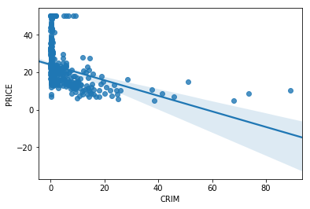

```python
# Seaborn is a statistical data visualization package
import seaborn as sns
# Use seaborn to visualize the trend
sns.regplot(x="CRIM", y = "PRICE", data=bos)
plt.show()
```

```python
# Import the object from linear_model
from sklearn.linear_model import LinearRegression
# Create an object
lm = LinearRegression()
# Fit PRICE and CRIM
# Here is another trick here. np.array(bos['CRIM']) returns a 1D array. But the coefficient matrix provided to lm.fit has to be 2D. So we use reshape to make it 2D.
lm.fit(X=np.array(bos['CRIM']).reshape(-1,1), y=bos['PRICE'])
# Report result
print('Intercept: ',  lm.intercept_)
print('Coefficient: ', lm.coef_)
```

```
Intercept:  24.03310617412388
Coefficient:  [-0.41519028]
```

So the fitted linear model is **PRICE = 24.03-0.42CRIM**. The next step is to compute the p-value of the coefficient and its confidence intervals. However, sklearn does not provide that information. You can compte it following the formula taught in the class. Or you can use another package called *statsmodels*.

```python
# Import statsmodels to do the linear regression
import statsmodels.api as sm
# We need the intercept, so add a constant column
X = sm.add_constant(np.array(bos['CRIM']))
y = bos['PRICE']
# Fit the model using OLS (ordinary least square, as opposed to generalized least square)
lm1 = sm.OLS(y,X).fit()
print(lm1.summary())
```

```
                            OLS Regression Results
==============================================================================
Dep. Variable:                  PRICE   R-squared:                       0.151
Model:                            OLS   Adj. R-squared:                  0.149
Method:                 Least Squares   F-statistic:                     89.49
Date:                Mon, 29 Apr 2019   Prob (F-statistic):           1.17e-19
Time:                        19:48:30   Log-Likelihood:                -1798.9
No. Observations:                 506   AIC:                             3602.
Df Residuals:                     504   BIC:                             3610.
Df Model:                           1
Covariance Type:            nonrobust
==============================================================================
                 coef    std err          t      P>|t|      [0.025      0.975]
------------------------------------------------------------------------------
const         24.0331      0.409     58.740      0.000      23.229      24.837
x1            -0.4152      0.044     -9.460      0.000      -0.501      -0.329
==============================================================================
Omnibus:                      139.832   Durbin-Watson:                   0.713
Prob(Omnibus):                  0.000   Jarque-Bera (JB):              295.404
Skew:                           1.490   Prob(JB):                     7.14e-65
Kurtosis:                       5.264   Cond. No.                         10.1
==============================================================================

Warnings:
[1] Standard Errors assume that the covariance matrix of the errors is correctly specified.
```

We can also predict a new independent variable $x_0$.

```python
# Consider two observation of CRIM
test = np.array([0.005, 0.006])
test = sm.add_constant(test)
# Use the estimated lm1 object to predict PRICE for the new CRIM data
lm1.predict(test)
```

```
array([24.03103022, 24.03061503])
```

### Regression Diagnostics

Next we conduct some basic diagnostics for the regression model. We first plot the residual as a function of the fitted value.

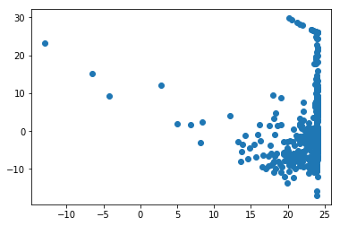

```python
# The results object has an attribute resid, representing the residuals
residual = lm1.resid
fitted = lm1.fittedvalues
# Next we plot it
plt.scatter(fitted, residual)
plt.show()
```

The residuals do not seem to be i.i.d.; there is a downward trend in the fitted value. Next we check the QQ-plot (normal probability plot) for normality. Scipy has a function for that.

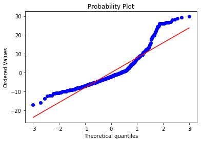

```python
# We first create an axis handle to plot
fig=plt.figure()
ax = fig.add_subplot(111)
# Use the scipy package
st.probplot(residual, dist='norm', plot=ax)
plt.show()
```

The normality assumption doesn't seem to be satisfied either.

## Multiple Linear Regression

Next we perform regression on all the variables to predict housing prices in Boston. We will still be using the statsmodel package.

```python
# Specify the matrices
X = sm.add_constant(bos.drop('PRICE', axis = 1))
y = bos['PRICE']
lm2 = sm.OLS(y,X).fit()
# Show results
print(lm2.summary())
```

```
                            OLS Regression Results
==============================================================================
Dep. Variable:                  PRICE   R-squared:                       0.741
Model:                            OLS   Adj. R-squared:                  0.734
Method:                 Least Squares   F-statistic:                     108.1
Date:                Mon, 29 Apr 2019   Prob (F-statistic):          6.72e-135
Time:                        19:48:30   Log-Likelihood:                -1498.8
No. Observations:                 506   AIC:                             3026.
Df Residuals:                     492   BIC:                             3085.
Df Model:                          13
Covariance Type:            nonrobust
==============================================================================
                 coef    std err          t      P>|t|      [0.025      0.975]
------------------------------------------------------------------------------
const         36.4595      5.103      7.144      0.000      26.432      46.487
CRIM          -0.1080      0.033     -3.287      0.001      -0.173      -0.043
ZN             0.0464      0.014      3.382      0.001       0.019       0.073
INDUS          0.0206      0.061      0.334      0.738      -0.100       0.141
CHAS           2.6867      0.862      3.118      0.002       0.994       4.380
NOX          -17.7666      3.820     -4.651      0.000     -25.272     -10.262
RM             3.8099      0.418      9.116      0.000       2.989       4.631
AGE            0.0007      0.013      0.052      0.958      -0.025       0.027
DIS           -1.4756      0.199     -7.398      0.000      -1.867      -1.084
RAD            0.3060      0.066      4.613      0.000       0.176       0.436
TAX           -0.0123      0.004     -3.280      0.001      -0.020      -0.005
PTRATIO       -0.9527      0.131     -7.283      0.000      -1.210      -0.696
B              0.0093      0.003      3.467      0.001       0.004       0.015
LSTAT         -0.5248      0.051    -10.347      0.000      -0.624      -0.425
==============================================================================
Omnibus:                      178.041   Durbin-Watson:                   1.078
Prob(Omnibus):                  0.000   Jarque-Bera (JB):              783.126
Skew:                           1.521   Prob(JB):                    8.84e-171
Kurtosis:                       8.281   Cond. No.                     1.51e+04
==============================================================================

Warnings:
[1] Standard Errors assume that the covariance matrix of the errors is correctly specified.
[2] The condition number is large, 1.51e+04. This might indicate that there are
strong multicollinearity or other numerical problems.
```

The table is similar to above. You can see the confidence interval and $p$-value for each variables. For example, AGE seems to be independent of the housing price. So let's test a model in which the variable AGE is absent.

```python
print(lm2.f_test('AGE = 0'))
```

```
<F test: F=array([[0.00274601]]), p=0.9582293092054368, df_denom=492, df_num=1>
```

The $p$-value is exactly equal to the one produced by the table. In other words, we don't have to include AGE in the model. This f_test allows us to test whether *multiple* variables are zero.

```python
print(lm2.f_test('RM = TAX = 0'))
```

```
<F test: F=array([[49.425045]]), p=2.7542160322818655e-20, df_denom=492, df_num=2>
```

### Regression Plots

It is easy to plot diagonostic plots using statsmodels.

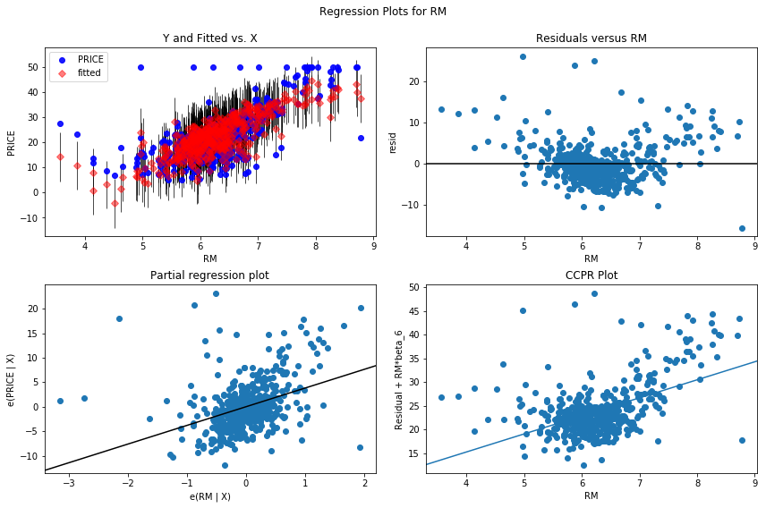

```python
fig = plt.figure(figsize = (12, 8))
fig = sm.graphics.plot_regress_exog(lm2, 'RM', fig=fig)
plt.show()
```